# SMAGL People

# SMAGL Principal Investigators

By now, you’ve probably already spoken to at least one of the two Principal Investigators (PI) in the SMAGL: **Dr. Eva C. Garrett** and **Dr. Christopher A. Schmitt**.

If you need them, you can contact and learn more about the SMAGL PIs in the following ways:

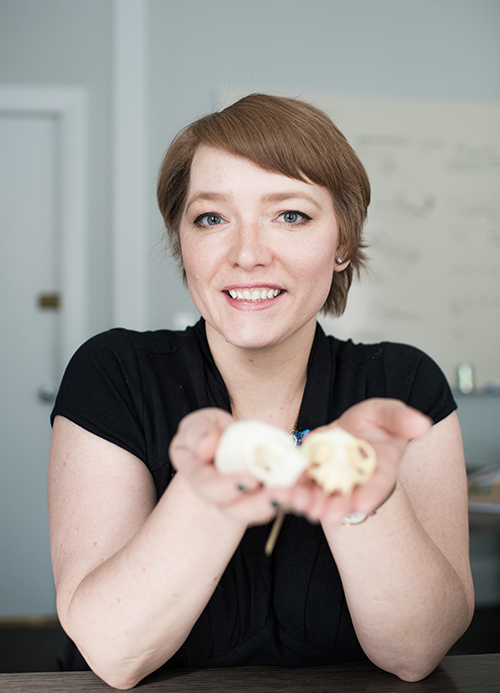

> [Prof. Eva C. Garrett](https://www.bu.edu/anthrop/profile/eva-garrett/) (she/her)  
> Office: Stone Science Building, 675 Commonwealth Ave, Room 247C  
> Phone: (617) 353-7709  
> Email: garrette@bu.edu  
> Webpage: http://www.ecgarrett.com  
> SocialMedia: @Shmevapithecus

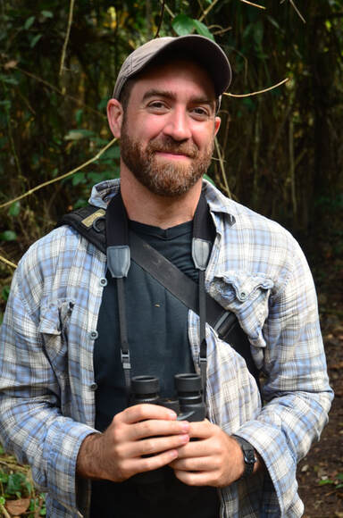

> [Prof. Christopher A. Schmitt](https://www.bu.edu/anthrop/profile/christopher-schmitt/). (he/they)  
> Office: Stone Science Building 675 Commonwealth Ave, Room 247E  
> Phone: (617) 353-5026  
> Email: caschmit@bu.edu  
> Webpage: http://www.evopropinquitous.net  
> SocialMedia: @fuzzyatelin

# SMAGL Students and Personnel

## SMAGL Lab Coordinator

[figure not shown]

The SMAGL Laboratory Coordinator and Lab Safety Coordinator is [**Dr. Christian Gagnon**](https://www.christianmgagnon.com) (he/him). Christian is the Lab Coordinator for all the labs associated with the Department of Anthropology, and can help with any safety or equipment concerns in the lab, the ordering of necessary supplies and many other day-to-day lab tasks. He is also a SMAGL Schmitt Lab alumnus! Christian earned his Ph.D. in Biological Anthropology with the SMAGL in 2024 with his dissertation on [*The Evolutionary History and Adaptive Significance of UCP1-Mediated Thermogenesis in Primates*](https://open.bu.edu/server/api/core/bitstreams/e050dc95-5aea-4534-91ad-47aae24ddb24/content), and developed our [vervet genomics pipeline](https://datadryad.org/dataset/doi:10.5061/dryad.k3j9kd59z).

Christian is most easily reached on the SMAGL Schmitt Lab Slack, via his office phone (617-353-5521), work email (cmgagnon@bu.edu) or in his office (STO 241; down the hall from the SMAGL lab space).

## Postdoctoral Research Associates

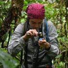

[**Dr. Evelyn L. Pain**](https://evelynpain.weebly.com) (she/her) is currently a **Postdoctoral Associate Teaching Scholar** in the Department of Biology affiliated with the Schmitt Lab, and Reserach Coordinator for the conservation NGO [Yunkawasi Perú](https://yunkawasiperu.org/en/). Her focus is on our primate projects in Perú, inclusing with yellow-tailed woolly monkeys (*Lagothrix flavicauda*) and Andean night monkeys (*Aotus miconax*). Dr. Pain’s current office space is in BRB 511.

When PRAs are working with the lab, please keep in mind that they are professional scientists with extensive field and lab experience, who have already earned a Ph.D., and who already run research programs of their own in addition to the research they conduct in the SMAGL. We ask that you respect the authority of our PRAs as strongly as you respect that of Prof. Garrett or Prof. Schmitt.

## Graduate Students

The SMAGL also trains graduate students at both the Master’s and Doctoral level. During your time in the SMAGL, one of the more senior graduate students may be assigned to be your immediate mentor.

Current graduate students you may meet include:

### Doctoral Students

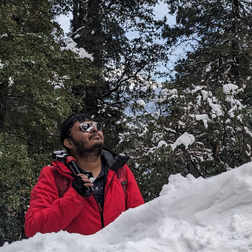

**Soumalya Ghorui** (Ph.D. Biological Anthropology; Schmitt Lab; he/him). Soumalya began in the Anthropology Ph.D. program in 2024. His research will focus on foraging behavior and diet as adaptations to the energetic constraints of high elevation living in wild Himalayan langurs (*Semnopithecus schistaceus*) with the [Himalayan Langur Project](https://www.himalayanlangur.com). His office is in the Biological Anthropology Graduate Student Space (STO 247).

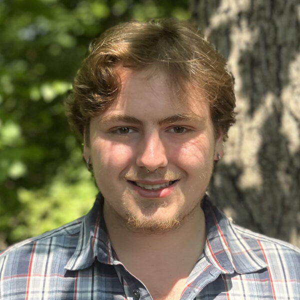

**Jimmy Erkens** (Ph.D. Biological Anthropology; Schmitt Lab; he/they). Jimmy began in the Anthropology Ph.D. program in 2023. His research focuses on using historical DNA methods to get DNA from museum specimens in order to fill in gaps in the population genetics of wild savanna monkeys (*Chlorocebus* spp.) to better understand their evolutionary history and taxonomy. His office is in the Biological Anthropology Graduate Student Space (STO 247).

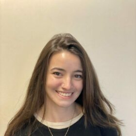

**Nicole Merullo** (Ph.D. Biological Anthropology; Hodges-Simeon and Schmitt Labs; she/her). Nicole began in the Anthropology Ph.D. program in 2023, in the Hodges-Simeon Lab. Her research, in collaboration with [Dr. Terry Capellini](https://heb.fas.harvard.edu/people/terence-capellini) at Harvard, focuses on using evolutionary developmental biology and gene expression methods to better understand the unique evolution of the human kidney, as a way of better understanding contemporary blood pressure phenotypes in humans. Her office is in the Biological Anthropology Graduate Student Space (STO 247).

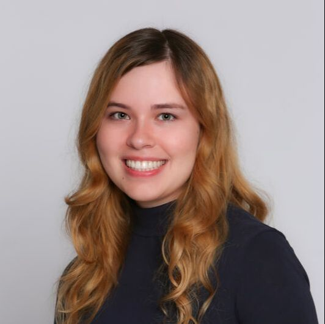

**Jess Martin** (Ph.D. Biological Anthropology; Schmitt Lab; she/her). Jess began in the Anthropology Ph.D. program in 2022. Her research focuses on dietary effects on the microbiome of wild vervet monkeys (*Chlroocebus pygerythrus pygerythrus*) across urban, farm, and Nature Reserve populations in South Africa. She will return from her fieldwork in August 2026. Her office is in the Biological Anthropology Graduate Student Space (STO 247).

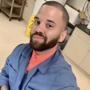

**Warrenkevin Henderson** (Ph.D. Biological Anthropology; Garrett and Schmitt Labs; he/him). Warrenkevin began in the Anthropology Ph.D. program in 2021, in the Garrett Lab. His research focuses on convergence related to cold adaptation in nasal morphology and associated genomic regions in ursids, phocids, equuids, and hominids. His office is in the SMAGL Dry Lab (STO 251).

### Masters Students

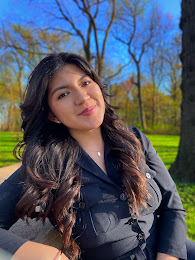

**Carly Rojas** (M.S. Biology – EBE, Schmitt Lab; she/her). Carla began in the Biology M.S. program in 2024, joining us from Universidad San Francisco de Quito in Ecuador, where she studied wild mantled howler monkeys (*Alouatta palliata aequatorialis*). She plans to work on diet in yellow-tailed woolly monkeys (*Lagothrix flavicauda*).

**Yinuo Mao** (M.S. Biology – CMB, Schmitt Lab; she/her). Yinuo began in the Biology M.S. program in 2024, joining us from UC Davis after some time in industry work. She will be conducting research into selection in the *ADIPOQ* gene in wild savanna monkeys (*Chlorocebus* spp.) using our genomics pipeline.

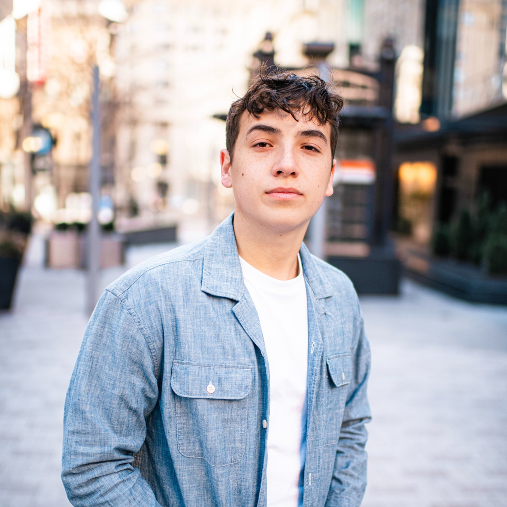

**Matteo Finnerty** (B.A./M.S. Biology - EBE, Schmitt Lab; he/him). Matteo joined the Schmitt Lab as an undergraduate, and joined the B.A./M.S. prgoram in Biology in 2025. Matteo’s research will focus on testing environmental DNA (eDNA) techniques to indirectly detect endangered primates in Andean Perú.

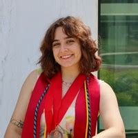

**Juliana Corn** (M.S. Biology – EBE, Schmitt Lab; she/her). Juliana joined the Schmitt Lab in the M.S. program in Biology in 2026. Juliana’s research in the lab will focus on the behavioral ecology of wild yellow-tailed woolly monkeys (*Lagothrix flavicauda*) at our research site at El Toro, Amazonas.

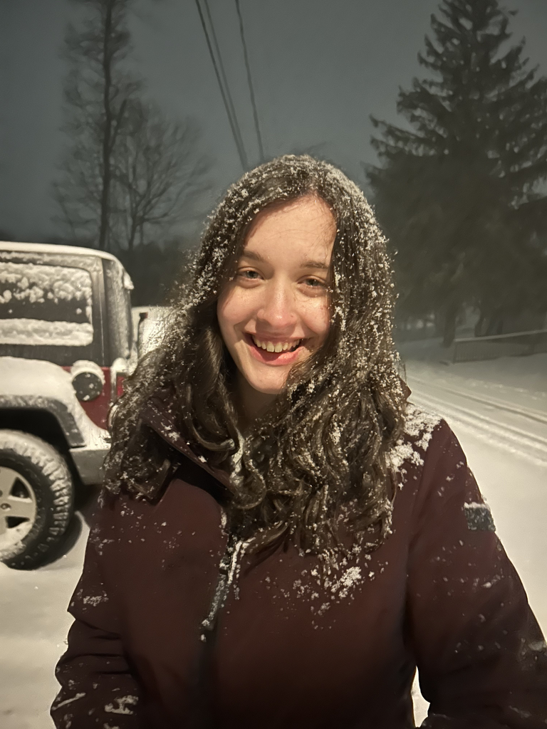

**Bonnie DiAngelis** (M.S. Biology – EBE, Schmitt Lab; she/her). Bonnie joined the Schmitt Lab in the M.S. program in Biology in 2026. Bonnie’s research in the lab has yet to be determined!

**Ji Young (Alex) Kim** (M.S. Biology – CMB, Schmitt Lab; she/her). Alex joined the Schmitt Lab in the M.S. program in Biology in 2026. Alex’s research in the lab will focus on gene expression patterns associated with a major drought in wild South African vervet monkeys (*Chorocebus pygerythrus*).

## Undergraduate Students

There are also several undergraduate students currently working in the SMAGL. These include, for the **Fall 2026** semester:

### Schmitt Lab Undergrads

**Claire Zhang** (Anthropology, Specialization in Biological Anthropology, Schmitt Lab; UROP; any pronouns)  
Honors Thesis: *Examining the influence of anthropogenic food consumption on circulating leptin and reproductive onset in wild South African vervet monkeys (Chlorocebus pygerythrus pygerythrus)*

**Alex Ortiz Gimenez Zapiola** (Biology, Specialization in Ecology and Conservation Biology, Schmitt Lab; he/him)  
Research Project (in collaboration with Dr. Eduardo Fernandez-Duque, Yale University): *Habitat Type and Feeding Behavior in Free-Ranging Azara’s Owl Monkeys (Aotus azarae) in the Argentine Chaco*

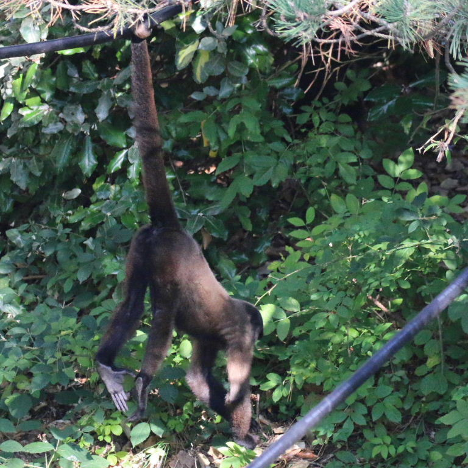

**Rhoda Ndukwe** (Biology, Specialization in Neuroscience, Schmitt Lab; UROP; she/her)  
UROP Project: *Re-evaluation of lowland woolly monkey (Lagothrix lagotricha subspp.) ranges in Perú using mitochondrial DNA markers*

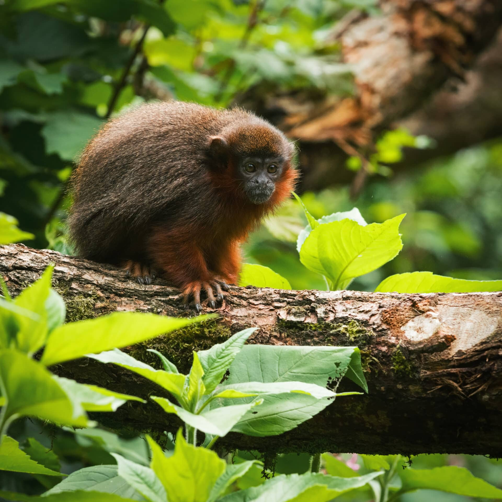

**Tad Matlock** (Biology, Specialization in Ecology and Conservation Biology, Schmitt Lab; he/him)  
Research Project (in collaboration with Dr. Gideon Erkenswick, Field Projects International): *Demographic analysis of mercury contamination in Amazonian primates at the Los Amigos Biological Station, Madre de Díos, Perú*

**Rose Mendez** (Anthropology, Specialization in Biological Anthropology, Schmitt Lab; she/her)  
Research Project: TBD

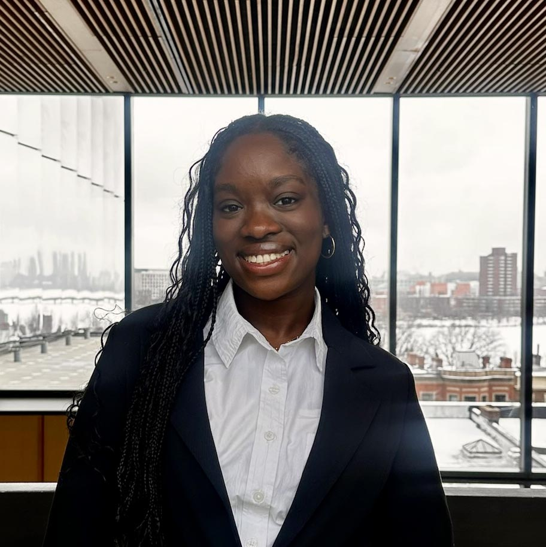

**Temilade Olateru-Olagbegi** (Biology, Schmitt Lab; she/her)  
Research Project: *Validating the use of Oxford Nanopore sequencing for the creation of local libraries to aid plant identification in dietary metabarcoding*

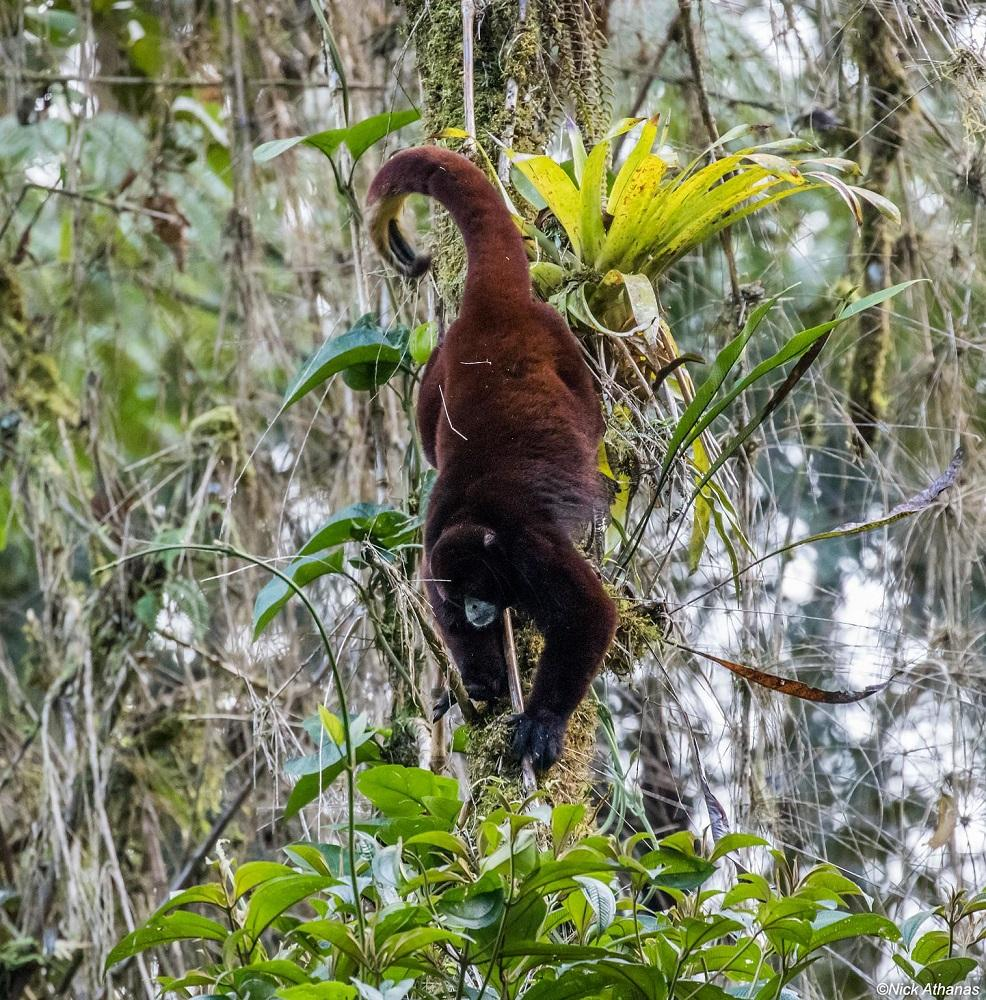

**Montse Duran de Huerta Arcelus** (Biology, Specialization in Neuroscience, Schmitt Lab; she/her)  
Research Project: TBD

**Pravin Mohan** (Anthropology, Specialization in Biological Anthropology, Schmitt Lab; he/him)  
Research Project: TBD

## SMAGL Alumni

The SMAGL has been in operation since 2017, and the Schmitt Lab since 2015. In that time, we’ve worked with a lot of amazing researchers who have helped to build our research program and push it in several new and exciting directions! SMAGL alumni include:

### Doctoral Students

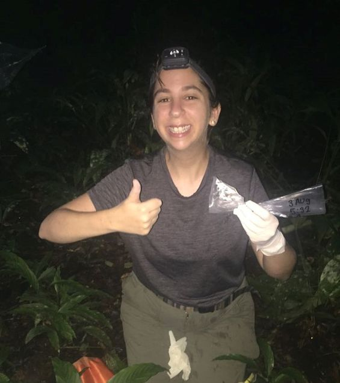

**Zoe Albert Miller** (Ph.D. 2026, Biological Anthropology, Knott and Schmitt Labs; she/her).  
Dissertation: *The Gut Microbiome as a Potential Modulator of Energetic Stress in Bornean Orangutans (Pongo pygmaeus)*

[figure not shown]

**Mel Zarate** (Ph.D. 2026, Biological Anthropology; Schmitt Lab; she/her).  
Dissertation: *Landscape Mitogenomics and High-Altitude Adaptation in the Peruvian Yellow-Tailed Woolly Monkey (Lagothrix flavicauda).*

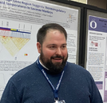

**Christian Gagnon** (Ph.D. 2024, Biological Anthropology, Schmitt Lab; he/him).  
Dissertation: *The Evolutionary History and Adaptive Significance of UCP1-Mediated Thermogenesis in Primates*

### Masters Students

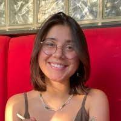

**Sofia Weaver** (B.A./M.S. 2026, Biology – EBE, Schmitt Lab; she/her).  
Thesis: *Investigating the Role of the Gut Microbiome in High-Altitude Adaptation of Woolly Monkeys (Lagothrix spp.) in Andean Perú*

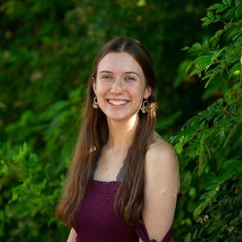

**Victoria Zdanowicz** (M.S., Biology – EBE, 2024, Knott and Schmitt Labs; she/her).  
Thesis: *Local ecology and dietary selectivity at indicators of differing orangutan habitat quality within Gunung Palung National Park, Borneo, Indonesia*

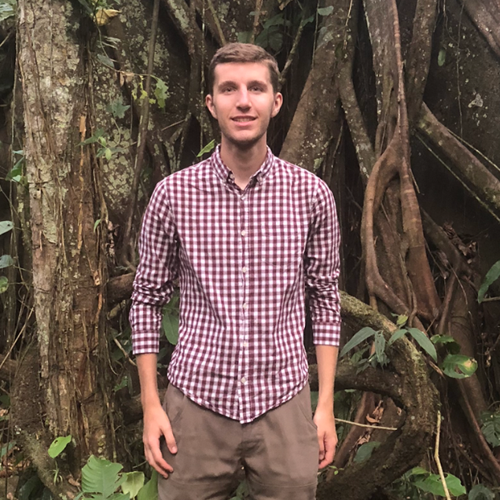

**Maxwell Dippel** (M.S. 2023, Biology – EBE, Schmitt Lab; he/him).  
Thesis: *Genetic Variation in Heat Shock Protein HSPA1L in Savanna Monkeys: Implications for Heat Resilience*

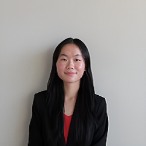

**Sophia Long** (B.A./M.S. 2023, Biology, Schmitt Lab; she/her).  
Thesis: Sophia chose a Coursework Masters in Biology, and so has no associated thesis.

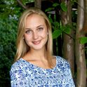

**Laura Angley** (M.S. 2021, Biology, Schmitt Lab; she/her).  
Thesis: *Post-Release Survival Rates and Welfare of Rehabilitated Vervet Monkeys in Malawi*

**Erica Sun** (B.A./M.S. 2021, Biology, Schmitt Lab; she/her).  
Thesis: *Selection in the PLIN2 (Perilipin-2) Gene Among Wild Savanna Monkeys (Chlorocebus spp.)*

[figure not shown]

**Mel Zarate** (M.S. 2020, Biology, Schmitt Lab; she/her).  
Thesis: *Predicting Suitable Habitat for the Critically Endangered Yellow-Tailed Woolly Monkey (Lagothrix flavicauda) in Perú*

### Undergraduate Students

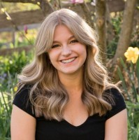

**Reese Hotten-Somers** (Anthropology, Specialization in Biological Anthropology, Schmitt Lab; she/they)  
Honors Thesis (2026): *The Comparative Gut Viromes of Wild Lowland (Lagothrix poeppigii) and Yellow-tailed Woolly Monkeys (Lagothrix flavicauda)*

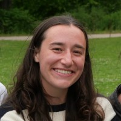

**Chloe Leaman** (Biology, Specialization in Cell Biology, Molecular Biology & Genetics, Schmitt Lab; she/her)  
Honors Thesis (2026): *The Evolution and Diversity of Major Histocompatibility Complex II gene DRB in wild yellow-tailed woolly monkeys (Lagothrix flavicauda)*

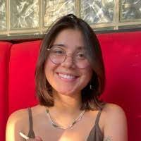

**Sofia Weaver** (Biology – EBE, Schmitt Lab; she/her).  
Honors Thesis (2025): *Sequencing of SRY to study sex-biased dispersal in the Critically Endangered yellow-tailed woolly monkey (Lagothrix flavicauda).*

**Noam Aviv** (Biology, Specialization in Behavioral Biology; he/him)  
Honors Thesis (2025): *Using Camera Traps to Assess Demography and Life History in wild Endangered Andean Night Monkeys (Aotus miconax)*

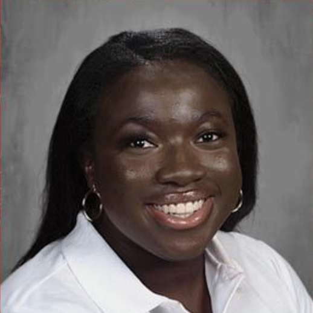

**Merilyn Amponsah-Asamoah** (Anthropology, Specialization in Anthropology, Health, and Medicine; she/her)

**Shaotai (Max) Hu** (Data Science, Minor in Statistical Methods; he/him)  
Research Project: Using AI to assess demography from camera trap data in wild Endangered Andean night monkeys (*Aotus miconax*)

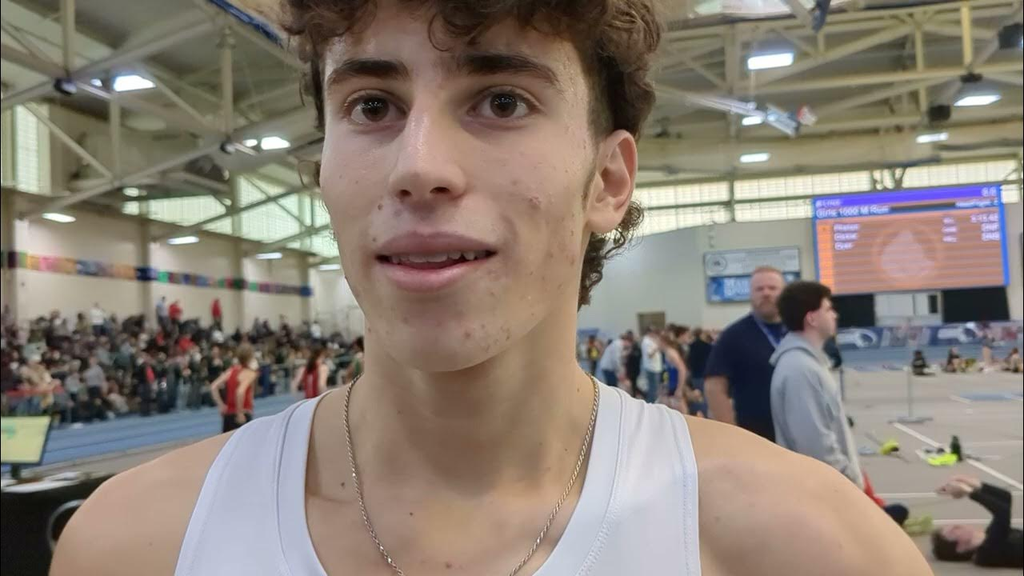

**Jacob Bronstein** (Biology, Specialization in Ecology and Conservation Biology, Schmitt Lab; UROP; he/him)  
UROP Project: *DNA metabarcoding of Peruvian woolly monkey (Lagothrix lagotricha tschudii) fecal samples to detect arthropod consumption*

# [**Back to the Guide**](https://fuzzyatelin.github.io/smagl_student_guide/overview.html)

# [**SMAGL *Undergraduate* Student Resources**](https://fuzzyatelin.github.io/smagl_student_guide/smagl_ugrad.html)

# [**SMAGL *Graduate* Student Resources**](https://fuzzyatelin.github.io/smagl_student_guide/smagl_grad.html)